# AnalysisGeometridNoctuidMothsEcography

Lea Heidrich

2 Februar 2021

# Description of RData:

- env: environmental variables, see Appendix S1
- moths_agg_fam: community weighted means, environmental variables, number of species, per plot, year and family, including the full gradient in 2016 (27+15 Plots)
- moths_agg_fam_bal: just as above, but for balanced data (excluding the 15 plots sampled in 2016 only)
- moths_M: species matrix, Geometridae & Noctuidae, years seperately (2x27+15 Plots)
- moths_M_bal: just as above, but without the 15 plots sampled in 2016 only
- species_lvl: Species sampled in 2016 (full gradient) and 2007 (27+15 Plots) with abundances and habitat availability
- species_lvl_bal: Species equally sampled in 2016 and 2007 (27 Plots)
- traits: traits extracted from Potocky et al, Altermatt & Pearse and own measurements
- plots: list of plots sampled equally in both years

load data and prepare graphical settings

```r
rm(list=ls())
library(ggplot2)
load("Input/GeoNoc.RData")
pal <- c( "#67a9cf","#ef8a62")
```

# Environment

Mean annual temperature and total annual precipitation per site were modelled by based on a terrain height model (SRTM), data from 38 climate stations and additional 139 precipitation via extrapolation using ArcEGMO (Becker et al. 2002). Canoy cover was calculated for all single trees with a breast height dbh of more than 7 cm in an area of 500 m² around site centre. For each tree, canopy cover was calculated based on Pretzsch et al. (2002), summed over all species per plot and multiplied by 20 to gain canopy cover per hectar

### average values

first line refers to the balances, second line to the full gradient, respectively. Note, that the latter includes modelled environmental information of the year 2007, though they had not been sampled

```r
env$year <- as.factor(env$year)

aggregate(temperature_year ~ year, env[env$Plot%in%plots,], function(x){summary(x)})
```

```
##   year temperature_year.Min. temperature_year.1st Qu. temperature_year.Median
## 1 2007              4.300300                 5.238150                6.183200
## 2 2016              4.095600                 4.967800                5.896300
##   temperature_year.Mean temperature_year.3rd Qu. temperature_year.Max.
## 1              5.971637                 6.549600              7.794700
## 2              5.744926                 6.269900              7.661300
```

```r
aggregate(temperature_year ~ year, env, function(x){summary(x)})
```

```
##   year temperature_year.Min. temperature_year.1st Qu. temperature_year.Median
## 1 2007              4.300300                 5.916850                6.641650
## 2 2016              4.095600                 5.752625                6.296700
##   temperature_year.Mean temperature_year.3rd Qu. temperature_year.Max.
## 1              6.968581                 7.916650             10.604800
## 2              6.849317                 8.163775             10.465100
```

```r
aggregate(precipitation ~ year, env[env$Plot%in%plots,], function(x){summary(x)})
```

```
##   year precipitation.Min. precipitation.1st Qu. precipitation.Median
## 1 2007           1451.372              1612.563             1675.417
## 2 2016           1118.826              1210.723             1255.423
##   precipitation.Mean precipitation.3rd Qu. precipitation.Max.
## 1           1764.296              1937.785           2212.227
## 2           1310.093              1393.218           1585.134
```

```r
aggregate(precipitation ~ year, env, function(x){summary(x)})
```

```
##   year precipitation.Min. precipitation.1st Qu. precipitation.Median
## 1 2007           942.2565             1315.8661            1604.7817
## 2 2016           907.7436             1087.2359            1204.0532
##   precipitation.Mean precipitation.3rd Qu. precipitation.Max.
## 1          1559.4584             1730.9804          2212.2265
## 2          1214.2109             1328.0068          1585.1337
```

```r
aggregate(crown_cover_ha ~ year, env[env$Plot%in%plots,], function(x){summary(x)})
```

```
##   year crown_cover_ha.Min. crown_cover_ha.1st Qu. crown_cover_ha.Median
## 1 2007             0.00000               27.50000              45.00000
## 2 2016             0.00000                8.50000              40.00000
##   crown_cover_ha.Mean crown_cover_ha.3rd Qu. crown_cover_ha.Max.
## 1            52.81481               87.50000           105.00000
## 2            48.14815               97.50000           120.00000
```

```r
aggregate(crown_cover_ha ~ year, env, function(x){summary(x)})
```

```
##   year crown_cover_ha.Min. crown_cover_ha.1st Qu. crown_cover_ha.Median
## 1 2007             0.00000               31.25000              70.00000
## 2 2016             0.00000               21.25000              60.00000
##   crown_cover_ha.Mean crown_cover_ha.3rd Qu. crown_cover_ha.Max.
## 1            60.14286               85.00000           120.00000
## 2            57.38095               90.00000           120.00000
```

#### Climate and Canopy Cover along elevation (Appendix Figure S1.1, left)

```r
temp_ele <- ggplot(data=env,
                      aes(elevation, temperature_year,col=year)) +
    scale_fill_manual(values = pal) +
    scale_color_manual(values = pal) +
  scale_x_continuous(breaks = seq(500, 1250, by = 250), limits = c(290,1370))+
  scale_y_continuous(breaks = seq(5, 10, by = 1), limits = c(4,11))+
  geom_point(data=env[!env$Plot%in%plots&env$year==2007,], pch=24)+
    geom_point(data=env[!env$Plot%in%plots&env$year==2016,], pch=17)+
  geom_point(data=env[env$Plot%in%plots,], pch=19)+
  geom_smooth(data=env[env$Plot%in%plots&env$year==2007,])+
  geom_smooth(data=env[env$Plot%in%plots&env$year==2016,])+
  geom_smooth(data=env[env$year==2016,], lty=3)+
  ylab("MAT (°C)")+
  xlab("")+
  theme(panel.background = element_rect(fill = "white", colour = "black"),
        axis.text = element_text(colour="black"),
         axis.title.x=element_blank(),
        axis.text.x  =element_blank(),
        axis.ticks.x=element_blank(), plot.margin = unit(c(0,0,0,-1), "cm"),
        legend.position="none")+
  guides(size=FALSE)

precip_ele <- ggplot(data=env,
                      aes(elevation, precipitation,colour=year)) +
    coord_cartesian(ylim=c(1000,2400))+
  scale_x_continuous(breaks = seq(500, 1250, by = 250), limits = c(290,1370))+
  scale_y_continuous(breaks = seq(1200, 2400, by = 400))+

  geom_point(data=env[!env$Plot%in%plots&env$year==2007,], pch=24)+
    scale_fill_manual(values = pal) +
    scale_color_manual(values = pal) +

    geom_point(data=env[!env$Plot%in%plots&env$year==2016,], pch=17)+
  geom_point(data=env[env$Plot%in%plots,], pch=19)+
    geom_smooth(data=env[env$Plot%in%plots&env$year==2007,])+
  geom_smooth(data=env[env$Plot%in%plots&env$year==2016,])+
  geom_smooth(data=env[env$year==2016,], lty=3)+

    ylab("Precipitation (mm)")+
  xlab("")+
  theme(panel.background = element_rect(fill = "white", colour = "black"),
        axis.text = element_text(colour="black"),
        axis.title.x=element_blank(),
        axis.text.x  =element_blank(),
        axis.ticks.x=element_blank(), plot.margin = unit(c(0,0,0,-1), "cm"),
        legend.position="none")+
  guides(size=FALSE)

cover_ele <- ggplot(data=env,
                      aes(elevation, crown_cover_ha,colour=year)) +

    scale_color_manual(values = pal) +
    scale_y_continuous(breaks = seq(0, 150, by = 50))+
  coord_cartesian(ylim=c(0,150))+
geom_point(data=env[!env$Plot%in%plots&env$year==2007,], pch=24)+
    geom_point(data=env[!env$Plot%in%plots&env$year==2016,], pch=17)+
  geom_point(data=env[env$Plot%in%plots,], pch=19)+
    geom_smooth(data=env[env$Plot%in%plots&env$year==2007,])+
  geom_smooth(data=env[env$Plot%in%plots&env$year==2016,])+
  geom_smooth(data=env[env$year==2016,], lty=3)+
  ylab("Crown cover (%)")+
  xlab("Elevation (m a.s.l)")+
  theme(panel.background = element_rect(fill = "white", colour = "black"),
        axis.text = element_text(colour="black"),plot.margin = unit(c(0,0,0,-1), "cm"),
        legend.position="none")+
  guides(size=FALSE)
```

#### Climate and Canopy Cover between both years (Appendix Figure S1.1, right)

```r
btemp <-  ggplot(env[env$Plot%in%plots,],
             aes(x=year, y=temperature_year, fill=year)) +
  scale_fill_manual(values = pal) +
  scale_y_continuous(breaks = seq(5, 10, by = 1), limits = c(4,11))+
  ylab("")+xlab("")+
  geom_boxplot(position=position_dodge(0.3))+
  theme(panel.background = element_rect(fill = "white", colour = "black"),
        axis.title=element_blank(),
        axis.text  =element_blank(),
        axis.ticks=element_blank(),
        plot.margin = unit(c(0,-1,0,0), "cm"),
        legend.position="none")

bprecip <-  ggplot(env[env$Plot%in%plots,],
             aes(x=year, y=precipitation, fill=year)) +
  scale_fill_manual(values = pal) +
  scale_y_continuous(breaks = seq(1200, 2400, by = 400), limits = c(1000,2400))+
  ylab("")+xlab("")+
  geom_boxplot(position=position_dodge(0.3))+

  theme(panel.background = element_rect(fill = "white", colour = "black"),
        axis.title=element_blank(),
        axis.text  =element_blank(),
        axis.ticks=element_blank(),
        plot.margin = unit(c(0,-1,0,0), "cm"),
        legend.position="none")

bcover <-  ggplot(env[env$Plot%in%plots,],
             aes(x=year, y=crown_cover_ha, fill=year)) +
  scale_fill_manual(values = pal) +
  scale_y_continuous(breaks = seq(0, 150, by = 50), limits = c(-10,150))+
  ylab("")+xlab("Year")+
  geom_boxplot(position=position_dodge(0.3))+
  theme(panel.background = element_rect(fill = "white", colour = "black"),
        axis.text = element_text(colour="black"),axis.title.y=element_blank(),
        axis.text.y  =element_blank(),
        axis.ticks.y=element_blank(),plot.margin = unit(c(0,-1,0,0), "cm"),
        legend.position="none")
```

combine graphs

```r
library(patchwork)

AppFig1 <-
  temp_ele+btemp+
  precip_ele+bprecip+
  cover_ele+bcover+
    plot_layout(widths = c(2, 1))

ggsave("Output/Appendix_Figure1.tiff",dpi=900,
       width = 166,height=160, unit="mm")
rm(temp_ele, btemp, precip_ele, bprecip, cover_ele, bcover, AppFig1)
```

# Ecological differences between families

#### species level differences in colour lightness and wing span between families

t-tests to evaluate the differences in both traits:

```r
summary(traits$meanRGB);sd(traits$meanRGB)
```

```
##    Min. 1st Qu.  Median    Mean 3rd Qu.    Max.
##  0.3427  0.4578  0.5443  0.5503  0.6245  0.8203
```

```
## [1] 0.1054538
```

```r
t.test(meanRGB~Family,data=traits)
```

```
##
##  Welch Two Sample t-test
##
## data:  meanRGB by Family
## t = 14.549, df = 247.51, p-value < 2.2e-16
## alternative hypothesis: true difference in means is not equal to 0
## 95 percent confidence interval:
##  0.1227265 0.1611572
## sample estimates:
## mean in group Geometridae   mean in group Noctuidae
##                 0.6186989                 0.4767571
```

```r
summary(traits$Wing.span);sd(traits$Wing.span)
```

```
##    Min. 1st Qu.  Median    Mean 3rd Qu.    Max.
##   16.00   26.00   31.00   31.71   37.00   55.00
```

```
## [1] 8.191637
```

```r
t.test(Wing.span~Family,data=traits)
```

```
##
##  Welch Two Sample t-test
##
## data:  Wing.span by Family
## t = -9.6044, df = 248.47, p-value < 2.2e-16
## alternative hypothesis: true difference in means is not equal to 0
## 95 percent confidence interval:
##  -10.228907  -6.747566
## sample estimates:
## mean in group Geometridae   mean in group Noctuidae
##                  27.61832                  36.10656
```

```r
aggregate(meanRGB ~ Family, traits, function(x){paste0(round(mean(x),2), " +/- ", round(sd(x),2))})
```

```
##        Family       meanRGB
## 1 Geometridae 0.62 +/- 0.08
## 2   Noctuidae 0.48 +/- 0.07
```

```r
aggregate(Wing.span ~ Family, traits, function(x){paste0(round(mean(x),2), " +/- ", round(sd(x),2))})
```

```
##        Family      Wing.span
## 1 Geometridae 27.62 +/- 6.92
## 2   Noctuidae 36.11 +/- 7.12
```

create the graph (Main Figure 2)

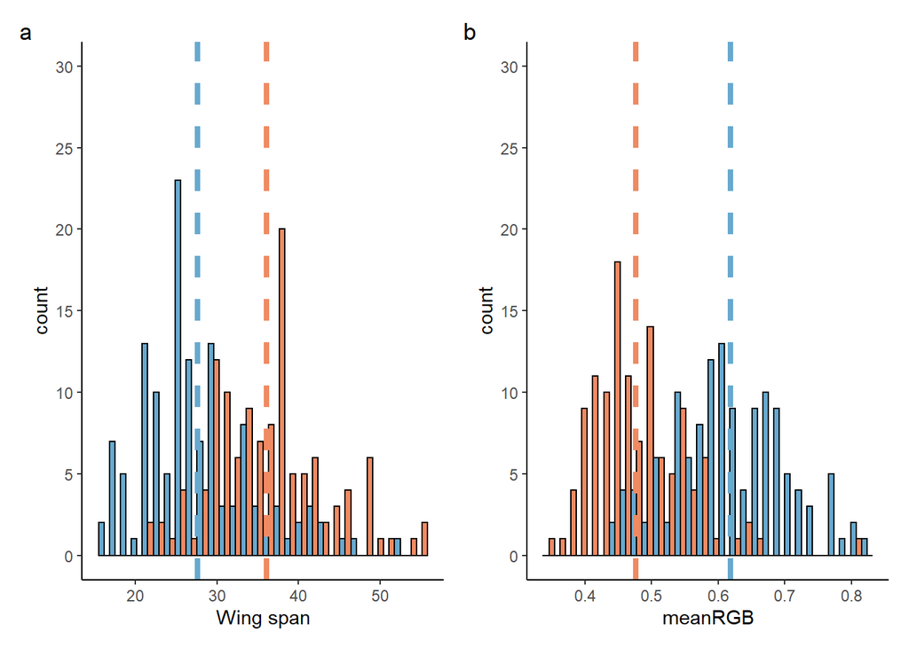

```r
library(plyr)
hRGB <- ggplot(traits,
       aes(x = meanRGB, fill = Family))+
  scale_y_continuous(breaks=seq(0, 30, 5), limits=c(0, 30))+
  geom_histogram(colour="black",  position = "dodge") +
  geom_vline(data=plyr::ddply(traits,
                              "Family",summarize, grp.mean=mean(meanRGB, na.rm=T)),
             aes(xintercept=grp.mean), colour=pal,
             linetype="dashed", lwd = 1.5) +
  scale_fill_manual(breaks = "Family",values = pal)+
  xlab("meanRGB") +
  theme_classic()+ theme(legend.position = "none")

hwing <- ggplot(traits,
       aes(x = Wing.span, fill = Family))+
  scale_y_continuous(breaks=seq(0, 30, 5), limits=c(0, 30))+
  geom_histogram(colour="black",  position = "dodge") +
  geom_vline(data=plyr::ddply(traits,
                              "Family", summarise, grp.mean=mean(Wing.span)),
             aes(xintercept=grp.mean),
             linetype="dashed", color=pal,lwd = 1.5) +
  scale_fill_manual(breaks = "Family",values = pal)+
  xlab("Wing span") +
  theme_classic()+ theme(legend.position = "none")


hwing+hRGB+  plot_annotation(tag_levels = 'a')
```

```r
ggsave("Output/Main_Figure2.tiff",dpi=900,
       width = 166,height=80, unit="mm")
rm(hwing, hRGB)
```

### Differences in life history

traits extracted from Potocky et al (2018) https://onlinelibrary.wiley.com/doi/epdf/10.1111/icad.12291

Kruskal-Wallis test to for differences related to voltinism and overwintering stage and percentages per level. Species which are overwintering as larvae or pupae (in Potocky marked as Overwintering =2.5) were considered as species overwintering as larvae

```r
kruskal.test(Voltinism ~ Family,
             data = traits)
```

```
##
##  Kruskal-Wallis rank sum test
##
## data:  Voltinism by Family
## Kruskal-Wallis chi-squared = 9.6838, df = 1, p-value = 0.001859
```

```r
t <-  table(traits$Family,
      traits$Voltinism)
t[1,]/sum(t[1,]);t[2,]/sum(t[2,])
```

```
##        1        2
## 0.519084 0.480916
```

```
##         1         2
## 0.7107438 0.2892562
```

```r
traits[which(traits$Overwintering>=2&traits$Overwintering<3),"Overwintering"] <- 2
traits$Overwintering <- as.factor(as.character(traits$Overwintering))

kruskal.test(Overwintering ~ Family,
             data = traits)
```

```
##
##  Kruskal-Wallis rank sum test
##
## data:  Overwintering by Family
## Kruskal-Wallis chi-squared = 10.289, df = 1, p-value = 0.001338
```

```r
t <-  table(traits$Family,
            traits$Overwintering)
t[1,]/sum(t[1,]);t[2,]/sum(t[2,])
```

```
##           1           2           3           4
## 0.099236641 0.343511450 0.549618321 0.007633588
```

```
##          1          2          3          4
## 0.09917355 0.58677686 0.29752066 0.01652893
```

graph the results (Appendix Figure S2.1)

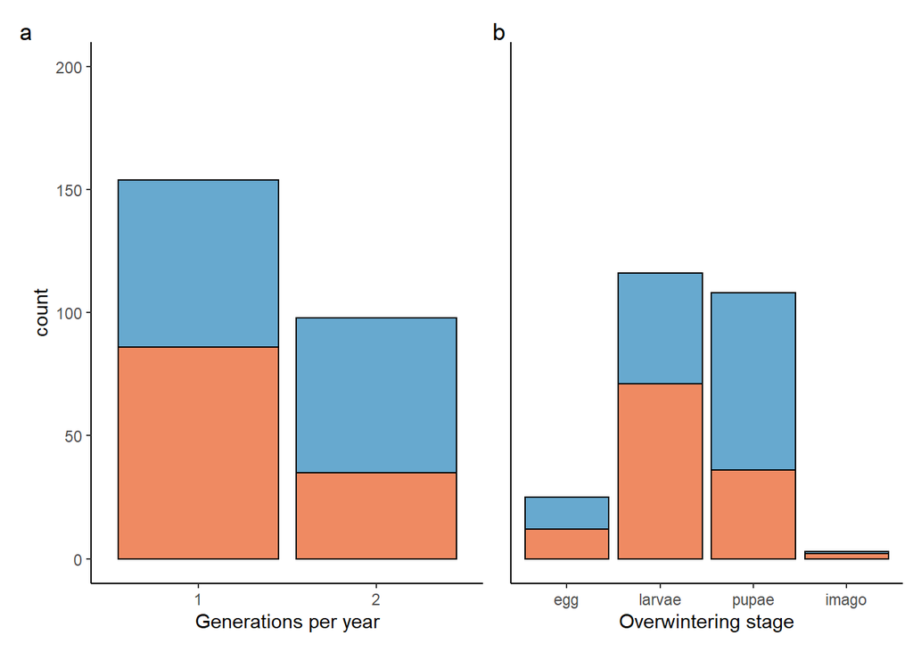

```r
traits$Voltinism <- as.factor(as.character(traits$Voltinism))

bvolt <- ggplot(na.omit(traits[,c("Family", "Voltinism")]),
       aes(x = Voltinism, fill = Family))+
  scale_y_continuous(breaks=seq(0, 200, 50), limits=c(0, 200))+
  geom_bar(colour="black") +
  scale_fill_manual(breaks = "Familie",values = pal)+
  xlab("Generations per year") +
  theme_classic()+ theme(legend.position = "none")

bwinter <- ggplot(na.omit(traits[,c("Family", "Overwintering")]),
       aes(x = Overwintering, fill = Family))+
  scale_y_continuous(breaks=seq(0, 200, 50), limits=c(0, 200))+
  scale_fill_manual(breaks = "Family",values = pal)+
  scale_x_discrete(breaks=c("1","2","3", "4"),
        labels=c("egg", "larvae", "pupae", "imago"))+
  geom_bar(colour="black") +
  xlab("Overwintering stage") +
  theme_classic()+
  theme(axis.title.y=element_blank(),
        axis.text.y  =element_blank(),
        axis.ticks.y=element_blank(),plot.margin = unit(c(0,-1,0,0), "cm"))

bvolt+bwinter+  plot_annotation(tag_levels = 'a')
```

```r
ggsave("Output/Appendix_S2_lifehistory.tiff",dpi=900,
       width = 166,height=100, unit="mm")
rm(bvolt, bwinter)
```

### traits related to feeding

Preferred host plant form, trophic range and whether adults are feeding were extracted from Potocky et al (2018) https://onlinelibrary.wiley.com/doi/epdf/10.1111/icad.12291. Only three species are not feeding as adults. Thus, differences in adult feeding were not depicted. Information about the number of plant species which the adults visit were taken from Altermatt & Pearse (2011) https://pubmed.ncbi.nlm.nih.gov/21828993/

```r
traits$Host_form <- as.factor(as.character(traits$Host_form))
kruskal.test(Host_form ~ Family,
             data = traits[traits$Host_form!=5,])
```

```
##
##  Kruskal-Wallis rank sum test
##
## data:  Host_form by Family
## Kruskal-Wallis chi-squared = 16.964, df = 1, p-value = 3.809e-05
```

```r
t <-  table(traits$Family,
      traits$Host_form)
t[1,]/sum(t[1,]);t[2,]/sum(t[2,])
```

```
##           1           2           3           4           5
## 0.259541985 0.007633588 0.221374046 0.503816794 0.007633588
```

```
##           1           2           3           4           5
## 0.264462810 0.272727273 0.256198347 0.198347107 0.008264463
```

```r
kruskal.test(Adult_feeding ~ Family,
             data = traits)
```

```
##
##  Kruskal-Wallis rank sum test
##
## data:  Adult_feeding by Family
## Kruskal-Wallis chi-squared = 4.6931, df = 1, p-value = 0.03028
```

```r
t <-  table(traits$Family,
      traits$Trophic.range)
t[1,]/sum(t[1,]);t[2,]/sum(t[2,])
```

```
##         1         2         3
## 0.4045802 0.1832061 0.4122137
```

```
##         1         2         3
## 0.1239669 0.2231405 0.6528926
```

```r
kruskal.test(Trophic.range ~ Family,
             data = traits)
```

```
##
##  Kruskal-Wallis rank sum test
##
## data:  Trophic.range by Family
## Kruskal-Wallis chi-squared = 21.645, df = 1, p-value = 3.28e-06
```

```r
t <-  table(traits$Family,
      traits$Trophic.range)
t[1,]/sum(t[1,]);t[2,]/sum(t[2,])
```

```
##         1         2         3
## 0.4045802 0.1832061 0.4122137
```

```
##         1         2         3
## 0.1239669 0.2231405 0.6528926
```

```r
nectr <- glm(Nr_Ahost~Family, data=traits, family="poisson")
summary(nectr)
```

```
##
## Call:
## glm(formula = Nr_Ahost ~ Family, family = "poisson", data = traits)
##
## Deviance Residuals:
##     Min       1Q   Median       3Q      Max
## -2.5495  -1.8046  -1.4638   0.2811  17.9182
##
## Coefficients:
##                 Estimate Std. Error z value Pr(>|z|)
## (Intercept)      0.48755    0.07372   6.613 3.76e-11 ***
## FamilyNoctuidae  0.69111    0.09226   7.491 6.84e-14 ***
## ---
## Signif. codes:  0 '***' 0.001 '**' 0.01 '*' 0.05 '.' 0.1 ' ' 1
##
## (Dispersion parameter for poisson family taken to be 1)
##
##     Null deviance: 1249.7  on 212  degrees of freedom
## Residual deviance: 1191.0  on 211  degrees of freedom
##   (40 observations deleted due to missingness)
## AIC: 1541.9
##
## Number of Fisher Scoring iterations: 6
```

graph the results (Appendix Figure S2.2)

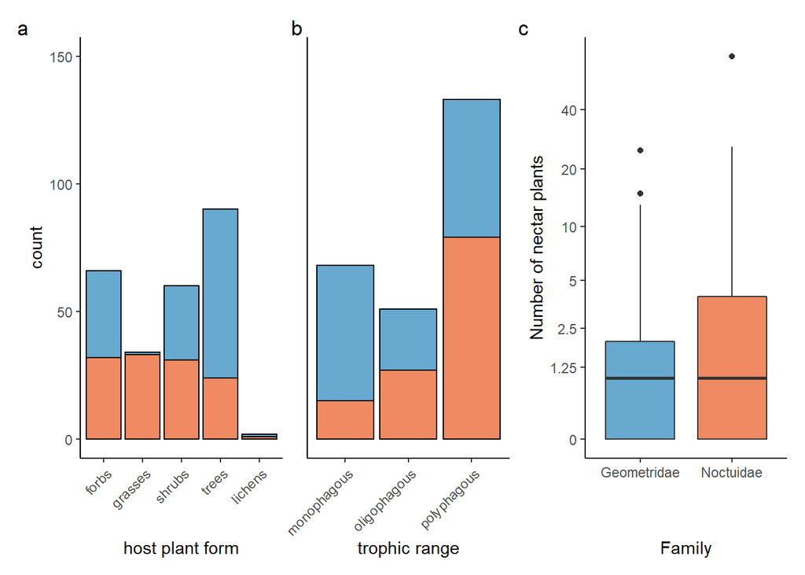

```r
bhost <- ggplot(na.omit(traits[,c("Family", "Host_form")]),
       aes(x = Host_form, fill = Family))+
  scale_y_continuous(breaks=seq(0, 150, 50), limits=c(0, 150))+
  geom_bar(colour="black") +
  scale_fill_manual(breaks = "Familie",values = pal)+
  xlab("host plant form") +
  scale_x_discrete(breaks=c("1","2","3","4","5"),
        labels=c("forbs", "grasses", "shrubs", "trees", "lichens"))+
  theme_classic()+ theme(legend.position = "none",axis.text.x = element_text(angle = 45, hjust = 1))

traits$Trophic.range <- as.factor(as.character(traits$Trophic.range))
btrophic <- ggplot(na.omit(traits[,c("Trophic.range", "Family")]),
       aes(x = Trophic.range, fill = Family))+
  scale_y_continuous(breaks=seq(0, 150, 50), limits=c(0, 150))+
  geom_bar(colour="black") +
  scale_fill_manual(breaks = "Familie",values = pal)+
  scale_x_discrete(breaks=c("1","2","3"), labels=c("monophagous", "oligophagous", "polyphagous"))+
  xlab("trophic range") +
  theme_classic()+ theme(legend.position = "none", axis.text.y=element_blank(),
                         axis.title.y = element_blank(),
                         axis.text.x = element_text(angle = 45, hjust = 1),
        axis.ticks.y=element_blank(),plot.margin = unit(c(0,-1,0,0), "cm"))


traits$Nr_Ahost <- log(traits$Nr_Ahost+1)

bAhost <- ggplot(traits,
       aes(x = Family, y= Nr_Ahost, fill = Family))+
  geom_boxplot() +
  scale_y_continuous(breaks=c(0,0.8109302,1.252763,1.791759,2.397895,3.044522,3.713572), labels=c("0","1.25","2.5","5","10","20","40"))+
  scale_fill_manual(breaks = "Familie",values = pal)+
  ylab("Number of nectar plants")+
  theme_classic()+ theme(legend.position = "none")


bhost+btrophic+bAhost+  plot_annotation(tag_levels = 'a')
```

```r
ggsave("Output/Appendix_S2_feeding.tiff",dpi=900,
       width = 166,height=80, unit="mm")
rm(bhost,btrophic,bAhost)
```

### traits related to habitat / canopy cover

Preferred habitat type were extracted from Potocky et al (2018) https://onlinelibrary.wiley.com/doi/epdf/10.1111/icad.12291. Habitat is ranked from 1 = grass- over 2= shrub- to 3 = woodland, though intermediate ranks are also given in Potocky et al (2018). For simplification, we rounded those intermediate levels of for the kruskal-wallis test. To evaluate the effect of preferred habitat type on color lightness and wing span, we simplified these level even more and aggregated the habitat types grass- and shrubland to the category "open habitat". The effect of the preferred habitat type on both traits was tested using a linear model, which included family as interaction term

```r
traits[which(findInterval(traits$Habitat_3D, c(1, 1.51))==1L),"Habitat_3D"] <- 1
traits[which(findInterval(traits$Habitat_3D, c(1.51, 2.4))==1L),"Habitat_3D"] <-2
traits[which(findInterval(traits$Habitat_3D, c(2.5, 3))==1L),"Habitat_3D"] <-3

kruskal.test(Habitat_3D ~ Family,
             data = traits[traits$Species%in%spec_bal,])#plot(habitat)
```

```
##
##  Kruskal-Wallis rank sum test
##
## data:  Habitat_3D by Family
## Kruskal-Wallis chi-squared = 14.043, df = 1, p-value = 0.0001786
```

```r
t <-  table(traits$Family,
            traits$Habitat_3D)
t[1,]/sum(t[1,]);t[2,]/sum(t[2,])
```

```
##          1          2          3
## 0.04580153 0.12977099 0.82442748
```

```
##         1         2         3
## 0.3223140 0.2396694 0.4380165
```

```r
traits$habitat <- NA
traits[which(traits$Habitat_3D <=2),"habitat"] <- "open"
traits[which(traits$Habitat_3D >2),"habitat"] <- "closed"

traits$habitat <- as.factor(traits$habitat)
traits$Family <- as.factor(traits$Family)


habitatColFam <- lm(meanRGB ~ habitat*Family, data=traits)
summary(habitatColFam)
```

```
##
## Call:
## lm(formula = meanRGB ~ habitat * Family, data = traits)
##
## Residuals:
##      Min       1Q   Median       3Q      Max
## -0.17172 -0.05302 -0.01189  0.05506  0.33249
##
## Coefficients:
##                              Estimate Std. Error t value Pr(>|t|)
## (Intercept)                  0.622018   0.007534  82.559   <2e-16 ***
## habitatopen                 -0.018905   0.017981  -1.051    0.294
## FamilyNoctuidae             -0.146773   0.013131 -11.177   <2e-16 ***
## habitatopen:FamilyNoctuidae  0.020882   0.023003   0.908    0.365
## ---
## Signif. codes:  0 '***' 0.001 '**' 0.01 '*' 0.05 '.' 0.1 ' ' 1
##
## Residual standard error: 0.0783 on 248 degrees of freedom
##   (1 observation deleted due to missingness)
## Multiple R-squared:  0.4573, Adjusted R-squared:  0.4508
## F-statistic: 69.67 on 3 and 248 DF,  p-value: < 2.2e-16
```

```r
habitatWingFam <- lm(Wing.span ~ habitat*Family, data=traits)
summary(habitatWingFam)
```

```
##
## Call:
## lm(formula = Wing.span ~ habitat * Family, data = traits)
##
## Residuals:
##      Min       1Q   Median       3Q      Max
## -13.8679  -4.8235  -0.8241   3.5439  24.1759
##
## Coefficients:
##                             Estimate Std. Error t value Pr(>|t|)
## (Intercept)                  27.8241     0.6699  41.536  < 2e-16 ***
## habitatopen                  -1.1719     1.5987  -0.733    0.464
## FamilyNoctuidae              10.0439     1.1675   8.603 9.01e-16 ***
## habitatopen:FamilyNoctuidae  -1.8725     2.0452  -0.916    0.361
## ---
## Signif. codes:  0 '***' 0.001 '**' 0.01 '*' 0.05 '.' 0.1 ' ' 1
##
## Residual standard error: 6.962 on 248 degrees of freedom
##   (1 observation deleted due to missingness)
## Multiple R-squared:  0.2891, Adjusted R-squared:  0.2805
## F-statistic: 33.62 on 3 and 248 DF,  p-value: < 2.2e-16
```

plot it

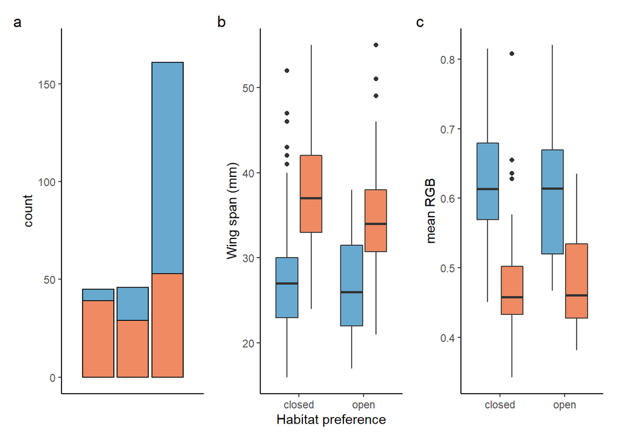

```r
bHab <- ggplot(na.omit(traits[,c("Habitat_3D", "Family")]),
                aes(x = Habitat_3D, fill = Family))+
  scale_y_continuous(breaks=seq(0, 150, 50), limits=c(0, 170))+
  geom_bar(colour="black") +
  scale_fill_manual(breaks = "Familie",values = pal)+
  scale_x_discrete(breaks=c("1","2","3"), labels=c("grassland", "shrubland", "woodland"))+
  xlab("Habitat preference") +
  theme_classic()+ theme(legend.position = "none",axis.text.x = element_text(angle = 45, hjust = 1), axis.title.x = element_blank())

habcolFam <- ggplot(aes(y = meanRGB, x = habitat), data = na.omit(traits[,c("habitat", "Family", "meanRGB")]))+ geom_boxplot(aes(fill = Family))+
  scale_fill_manual(breaks = "Familie",values = pal)+
  ylab("mean RGB")+
  #stat_summary(fun.data=mean_se, colour="black", geom="errorbar", width=0.1 ) +
  #stat_summary(fun=mean, colour="black", geom="point") +
  theme_classic()+ theme(legend.position = "none", axis.title.x = element_blank())

habWingFam <- ggplot(aes(y = Wing.span, x = habitat), data = na.omit(traits[,c("habitat", "Family", "Wing.span")]))+ geom_boxplot(aes(fill = Family))+
  scale_fill_manual(breaks = "Familie",values = pal)+
    xlab("Habitat preference") +
  ylab("Wing span (mm)")+
  theme_classic()+ theme(legend.position = "none")

bHab+habWingFam+habcolFam+  plot_annotation(tag_levels = 'a')
```

```r
ggsave("Output/Appendix_S2_habitats.tiff",dpi=900,
       width = 166,height=80, unit="mm")

rm(bHab, habWingFam,habcolFam)
```

moreover, we wanted to assess whether host plant availability misses important aspects of habitat availability. We thus tested, whether the preferred host form correlated with the preferred habitat openess

```r
kruskal.test(Host_form ~ habitat, data=traits)
```

```
##
##  Kruskal-Wallis rank sum test
##
## data:  Host_form by habitat
## Kruskal-Wallis chi-squared = 72.935, df = 1, p-value < 2.2e-16
```

```r
HabHost <- ggplot(na.omit(traits[,c("habitat", "Host_form")]),
                aes(x = Host_form, fill = habitat))+
  scale_y_continuous(breaks=seq(0, 150, 50), limits=c(0, 170))+
  geom_bar(colour="black") +
  scale_fill_manual(breaks = "habitat",values = c("darkgreen","lightgreen"))+
  scale_x_discrete(breaks=c("1","2","3","4","5"),
        labels=c("forbs", "grasses", "shrubs", "trees", "lichens"))+
  xlab("Habitat preference") +
  theme_classic()+ theme(legend.position = "none",axis.text.x = element_text(angle = 45, hjust = 1), axis.title.x = element_blank())

ggsave("Output/Appendix_HabHost.png",dpi=900,
       width = 80,height=80, unit="mm")
rm(HabHost)
```

# ANALYIS I: Community weighted means

The relationship between community-weighted means and elevation was assessed using linear models. Primarily, we wanted to assess whether both families show any significant cline in their community weighted means along elevation (RGB1, Wing1). In a second step, we evaluated whether the slopes differ between both families by evaluating the significance of interaction between elevation and the factor family (RGB2, Wing2). Lastly, we evaluated whether the family-specific slopes change significantly between sampling years (RGB3, Wing3).

### wing span

```r
moths_agg_fam_bal$year <- as.factor(as.character(moths_agg_fam_bal$year))
moths_agg_fam_bal$elevation100 <- moths_agg_fam_bal$elevation/100


# check, whether the slopes per family&year are significant
wing1 <- lm(wing_w~Family+year+
             Family:year:elevation100,
           data =moths_agg_fam_bal)
summary(wing1) #grp wise slopes + intercepts
```

```
##
## Call:
## lm(formula = wing_w ~ Family + year + Family:year:elevation100,
##     data = moths_agg_fam_bal)
##
## Residuals:
##     Min      1Q  Median      3Q     Max
## -6.5910 -2.0884 -0.2817  2.1312  8.0860
##
## Coefficients:
##                                         Estimate Std. Error t value Pr(>|t|)
## (Intercept)                              37.6682     2.5051  15.037  < 2e-16
## FamilyNoctuidae                          -9.9145     2.8927  -3.427 0.000883
## year2016                                 -2.8457     2.8927  -0.984 0.327580
## FamilyGeometridae:year2007:elevation100  -0.3526     0.2376  -1.484 0.140916
## FamilyNoctuidae:year2007:elevation100     1.0253     0.2376   4.315 3.73e-05
## FamilyGeometridae:year2016:elevation100  -0.1924     0.2376  -0.810 0.419993
## FamilyNoctuidae:year2016:elevation100     1.2237     0.2376   5.150 1.29e-06
##
## (Intercept)                             ***
## FamilyNoctuidae                         ***
## year2016
## FamilyGeometridae:year2007:elevation100
## FamilyNoctuidae:year2007:elevation100   ***
## FamilyGeometridae:year2016:elevation100
## FamilyNoctuidae:year2016:elevation100   ***
## ---
## Signif. codes:  0 '***' 0.001 '**' 0.01 '*' 0.05 '.' 0.1 ' ' 1
##
## Residual standard error: 3.006 on 101 degrees of freedom
## Multiple R-squared:  0.5049, Adjusted R-squared:  0.4755
## F-statistic: 17.17 on 6 and 101 DF,  p-value: 1.364e-13
```

```r
wing2 <- lm(wing_w~year+Family*elevation100,
           data =moths_agg_fam_bal)
summary(wing2) # test whether resp. differs between groups (over the years)
```

```
##
## Call:
## lm(formula = wing_w ~ year + Family * elevation100, data = moths_agg_fam_bal)
##
## Residuals:
##     Min      1Q  Median      3Q     Max
## -6.7329 -2.0772 -0.2235  2.1074  8.1565
##
## Coefficients:
##                              Estimate Std. Error t value Pr(>|t|)
## (Intercept)                   36.7360     2.0512  17.909  < 2e-16 ***
## year2016                      -0.9812     0.5745  -1.708 0.090649 .
## FamilyNoctuidae               -9.9145     2.8723  -3.452 0.000809 ***
## elevation100                  -0.2725     0.1914  -1.424 0.157470
## FamilyNoctuidae:elevation100   1.3970     0.2706   5.162  1.2e-06 ***
## ---
## Signif. codes:  0 '***' 0.001 '**' 0.01 '*' 0.05 '.' 0.1 ' ' 1
##
## Residual standard error: 2.985 on 103 degrees of freedom
## Multiple R-squared:  0.5022, Adjusted R-squared:  0.4829
## F-statistic: 25.98 on 4 and 103 DF,  p-value: 6.718e-15
```

```r
wing3 <- lm(wing_w~ Family+
             year*Family:elevation100,
           data =moths_agg_fam_bal)
summary(wing3) # test whether resp. within families differs between years
```

```
##
## Call:
## lm(formula = wing_w ~ Family + year * Family:elevation100, data = moths_agg_fam_bal)
##
## Residuals:
##     Min      1Q  Median      3Q     Max
## -6.5910 -2.0884 -0.2817  2.1312  8.0860
##
## Coefficients:
##                                         Estimate Std. Error t value Pr(>|t|)
## (Intercept)                              37.6682     2.5051  15.037  < 2e-16
## FamilyNoctuidae                          -9.9145     2.8927  -3.427 0.000883
## year2016                                 -2.8457     2.8927  -0.984 0.327580
## FamilyGeometridae:elevation100           -0.3526     0.2376  -1.484 0.140916
## FamilyNoctuidae:elevation100              1.0253     0.2376   4.315 3.73e-05
## FamilyGeometridae:year2016:elevation100   0.1602     0.2780   0.576 0.565619
## FamilyNoctuidae:year2016:elevation100     0.1984     0.2780   0.714 0.477044
##
## (Intercept)                             ***
## FamilyNoctuidae                         ***
## year2016
## FamilyGeometridae:elevation100
## FamilyNoctuidae:elevation100            ***
## FamilyGeometridae:year2016:elevation100
## FamilyNoctuidae:year2016:elevation100
## ---
## Signif. codes:  0 '***' 0.001 '**' 0.01 '*' 0.05 '.' 0.1 ' ' 1
##
## Residual standard error: 3.006 on 101 degrees of freedom
## Multiple R-squared:  0.5049, Adjusted R-squared:  0.4755
## F-statistic: 17.17 on 6 and 101 DF,  p-value: 1.364e-13
```

### color lightness

```r
RGB1 <- lm(meanRGB_w~Family+year+
             Family:year:elevation100,
           data =moths_agg_fam_bal)
summary(RGB1) #grp wise slopes + intercepts
```

```
##
## Call:
## lm(formula = meanRGB_w ~ Family + year + Family:year:elevation100,
##     data = moths_agg_fam_bal)
##
## Residuals:
##       Min        1Q    Median        3Q       Max
## -0.075442 -0.012999 -0.000934  0.013863  0.056608
##
## Coefficients:
##                                          Estimate Std. Error t value Pr(>|t|)
## (Intercept)                              0.500709   0.019619  25.521  < 2e-16
## FamilyNoctuidae                          0.011088   0.022654   0.489 0.625600
## year2016                                 0.054500   0.022654   2.406 0.017961
## FamilyGeometridae:year2007:elevation100  0.007138   0.001861   3.836 0.000218
## FamilyNoctuidae:year2007:elevation100   -0.004280   0.001861  -2.300 0.023497
## FamilyGeometridae:year2016:elevation100  0.002299   0.001861   1.236 0.219490
## FamilyNoctuidae:year2016:elevation100   -0.008077   0.001861  -4.341 3.38e-05
##
## (Intercept)                             ***
## FamilyNoctuidae
## year2016                                *
## FamilyGeometridae:year2007:elevation100 ***
## FamilyNoctuidae:year2007:elevation100   *
## FamilyGeometridae:year2016:elevation100
## FamilyNoctuidae:year2016:elevation100   ***
## ---
## Signif. codes:  0 '***' 0.001 '**' 0.01 '*' 0.05 '.' 0.1 ' ' 1
##
## Residual standard error: 0.02354 on 101 degrees of freedom
## Multiple R-squared:  0.8438, Adjusted R-squared:  0.8345
## F-statistic: 90.93 on 6 and 101 DF,  p-value: < 2.2e-16
```

```r
RGB2 <- lm(meanRGB_w~year+Family*elevation100,
           data =moths_agg_fam_bal)
summary(RGB2) # test whether resp. differs between groups (over the years)
```

```
##
## Call:
## lm(formula = meanRGB_w ~ year + Family * elevation100, data = moths_agg_fam_bal)
##
## Residuals:
##       Min        1Q    Median        3Q       Max
## -0.073832 -0.013207 -0.000876  0.015507  0.053506
##
## Coefficients:
##                               Estimate Std. Error t value Pr(>|t|)
## (Intercept)                   0.523158   0.016457  31.789  < 2e-16 ***
## year2016                      0.009603   0.004609   2.083  0.03969 *
## FamilyNoctuidae               0.011088   0.023045   0.481  0.63144
## elevation100                  0.004718   0.001535   3.073  0.00271 **
## FamilyNoctuidae:elevation100 -0.010897   0.002171  -5.019 2.19e-06 ***
## ---
## Signif. codes:  0 '***' 0.001 '**' 0.01 '*' 0.05 '.' 0.1 ' ' 1
##
## Residual standard error: 0.02395 on 103 degrees of freedom
## Multiple R-squared:  0.8352, Adjusted R-squared:  0.8288
## F-statistic: 130.5 on 4 and 103 DF,  p-value: < 2.2e-16
```

```r
RGB3 <- lm(meanRGB_w~ Family+
             year*Family:elevation100,
           data =moths_agg_fam_bal)
summary(RGB3)
```

```
##
## Call:
## lm(formula = meanRGB_w ~ Family + year * Family:elevation100,
##     data = moths_agg_fam_bal)
##
## Residuals:
##       Min        1Q    Median        3Q       Max
## -0.075442 -0.012999 -0.000934  0.013863  0.056608
##
## Coefficients:
##                                          Estimate Std. Error t value Pr(>|t|)
## (Intercept)                              0.500709   0.019619  25.521  < 2e-16
## FamilyNoctuidae                          0.011088   0.022654   0.489 0.625600
## year2016                                 0.054500   0.022654   2.406 0.017961
## FamilyGeometridae:elevation100           0.007138   0.001861   3.836 0.000218
## FamilyNoctuidae:elevation100            -0.004280   0.001861  -2.300 0.023497
## FamilyGeometridae:year2016:elevation100 -0.004838   0.002177  -2.223 0.028474
## FamilyNoctuidae:year2016:elevation100   -0.003797   0.002177  -1.744 0.084160
##
## (Intercept)                             ***
## FamilyNoctuidae
## year2016                                *
## FamilyGeometridae:elevation100          ***
## FamilyNoctuidae:elevation100            *
## FamilyGeometridae:year2016:elevation100 *
## FamilyNoctuidae:year2016:elevation100   .
## ---
## Signif. codes:  0 '***' 0.001 '**' 0.01 '*' 0.05 '.' 0.1 ' ' 1
##
## Residual standard error: 0.02354 on 101 degrees of freedom
## Multiple R-squared:  0.8438, Adjusted R-squared:  0.8345
## F-statistic: 90.93 on 6 and 101 DF,  p-value: < 2.2e-16
```

plot cwm along elevation

```r
Wing_bal <- ggplot(data=moths_agg_fam_bal,
             aes(elevation, wing_w,colour=Family)) + geom_point(aes(size = nspec, pch=year)) +
  scale_colour_manual(breaks = "Family",values = pal) +
  ylab("Wing span (mm)")+
  scale_y_continuous(breaks = seq(25, 45, by = 5), limits = c(24,46))+
  geom_smooth(data=moths_agg_fam_bal[moths_agg_fam_bal$Family=="Geometridae"&moths_agg_fam_bal$year=="2007",],method="lm", lty=3,se=F, col="grey")+
  geom_smooth(data=moths_agg_fam_bal[moths_agg_fam_bal$Family=="Geometridae"&moths_agg_fam_bal$year=="2016",],method="lm", se=F, col="grey")+
  geom_smooth(data=moths_agg_fam_bal[moths_agg_fam_bal$Family=="Noctuidae"&moths_agg_fam_bal$year=="2007",],method="lm",lty=3, se=F, col="black")+
  geom_smooth(data=moths_agg_fam_bal[moths_agg_fam_bal$Family=="Noctuidae"&moths_agg_fam_bal$year=="2016",],method="lm", se=F, col="black")+
  xlab("elevation (m a.s.l)")+
  theme(panel.background = element_rect(fill = "white", colour = "black"),
        axis.text = element_text(colour="black"))+
  guides(size=FALSE)

RGB_bal <- ggplot(data=moths_agg_fam_bal,
             aes(elevation, meanRGB_w,colour=Family)) + geom_point(aes(size = nspec, pch=year)) +
  scale_colour_manual(breaks = "Family",values = pal) +
  ylab("mean RGB")+
  scale_y_continuous(breaks = seq(0.45, 0.65, by = 0.05), limits = c(0.43,0.67))+
    xlab("elevation (m a.s.l)")+
  geom_smooth(data=moths_agg_fam_bal[moths_agg_fam_bal$Family=="Geometridae"&moths_agg_fam_bal$year=="2007",],method="lm", lty=3,se=F, col="black")+
  geom_smooth(data=moths_agg_fam_bal[moths_agg_fam_bal$Family=="Geometridae"&moths_agg_fam_bal$year=="2016",],method="lm", se=F, col="grey")+
  geom_smooth(data=moths_agg_fam_bal[moths_agg_fam_bal$Family=="Noctuidae"&moths_agg_fam_bal$year=="2007",],method="lm",lty=3, se=F, col="black")+
  geom_smooth(data=moths_agg_fam_bal[moths_agg_fam_bal$Family=="Noctuidae"&moths_agg_fam_bal$year=="2016",],method="lm", se=F, col="black")+
  theme(panel.background = element_rect(fill = "white", colour = "black"),
        axis.text = element_text(colour="black"))
```

test for differances in average colour lightness between both years

```r
t.test(meanRGB_w~year, data =moths_agg_fam_bal[moths_agg_fam_bal$Family=="Noctuidae",])
```

```
##
##  Welch Two Sample t-test
##
## data:  meanRGB_w by year
## t = -2.5674, df = 47.238, p-value = 0.01347
## alternative hypothesis: true difference in means is not equal to 0
## 95 percent confidence interval:
##  -0.025552459 -0.003102434
## sample estimates:
## mean in group 2007 mean in group 2016
##          0.4676323          0.4819598
```

```r
t.test(meanRGB_w~year, data =moths_agg_fam_bal[moths_agg_fam_bal$Family=="Geometridae",])
```

```
##
##  Welch Two Sample t-test
##
## data:  meanRGB_w by year
## t = -0.57048, df = 51.94, p-value = 0.5708
## alternative hypothesis: true difference in means is not equal to 0
## 95 percent confidence interval:
##  -0.02203622  0.01228043
## sample estimates:
## mean in group 2007 mean in group 2016
##          0.5745841          0.5794620
```

```r
t.test(wing_w~year, data =moths_agg_fam_bal[moths_agg_fam_bal$Family=="Noctuidae",])
```

```
##
##  Welch Two Sample t-test
##
## data:  wing_w by year
## t = 0.7373, df = 51.98, p-value = 0.4643
## alternative hypothesis: true difference in means is not equal to 0
## 95 percent confidence interval:
##  -1.156740  2.500496
## sample estimates:
## mean in group 2007 mean in group 2016
##           38.35946           37.68758
```

```r
t.test(wing_w~year, data =moths_agg_fam_bal[moths_agg_fam_bal$Family=="Geometridae",])
```

```
##
##  Welch Two Sample t-test
##
## data:  wing_w by year
## t = 1.333, df = 51.775, p-value = 0.1884
## alternative hypothesis: true difference in means is not equal to 0
## 95 percent confidence interval:
##  -0.652417  3.233615
## sample estimates:
## mean in group 2007 mean in group 2016
##           34.05696           32.76636
```

plot differences between the years

```r
Wing_year <- ggplot(moths_agg_fam_bal,
             aes(x=year, y=wing_w, fill=Family)) +
  scale_fill_manual(values = pal) +
  scale_y_continuous(breaks = seq(25, 45, by = 5), limits = c(24,46))+
  ylab("")+
  geom_boxplot(position=position_dodge(0.3))+
  guides(fill = "legend")+
  theme(panel.background = element_rect(fill = "white", colour = "black"),
        axis.text = element_text(colour="black"))

RGB_year <- ggplot(moths_agg_fam_bal,
             aes(x=year, y=meanRGB_w, fill=Family)) +
  scale_fill_manual(values = pal) +
  scale_y_continuous(breaks = seq(0.45, 0.65, by = 0.05), limits = c(0.43,0.67))+
  ylab("")+
  geom_boxplot(position=position_dodge(0.3))+
  guides(fill = "legend")+
  theme(panel.background = element_rect(fill = "white", colour = "black"),
        axis.text = element_text(colour="black"))
```

combine figures (Main Figure 3)

```r
library(cowplot)
prow <- plot_grid(Wing_bal+ theme(legend.position="none"), Wing_year+
                    theme(legend.position="none"), RGB_bal+ theme(legend.position="none"), RGB_year+theme(legend.position="none"), labels = c('A',"", 'B',""),ncol = 2, nrow=2, align = "v", rel_widths = c(1,1))
legend_p <- get_legend(
  Wing_bal+
    guides(color = guide_legend(nrow = 1)) +
    theme(legend.position = "bottom")
)
legend_b <- get_legend(
Wing_year+    guides(color = guide_legend(nrow = 1)) +
    theme(legend.position = "bottom")
)


lrow <- plot_grid(legend_b, legend_p, ncol = 2)

f2 <- plot_grid(prow, lrow,ncol = 1, rel_heights = c(1, .1))

ggsave("Output/Main_Figure3.png",dpi=900,
       width = 166,height=170, unit="mm")
```

### test the cwm along elevation for the full gradient sampled in 2016

first row: test whether the family-specific slopes differs significantly from zero. second row: test whether families differ in slopes

```r
summary(lm(wing_w~Family+Family:elevation,data=moths_agg_fam[moths_agg_fam$year==2016,]))
```

```
##
## Call:
## lm(formula = wing_w ~ Family + Family:elevation, data = moths_agg_fam[moths_agg_fam$year ==
##     2016, ])
##
## Residuals:
##     Min      1Q  Median      3Q     Max
## -6.9984 -1.8535 -0.1207  2.0582  7.1674
##
## Coefficients:
##                              Estimate Std. Error t value Pr(>|t|)
## (Intercept)                 28.854669   1.234379  23.376  < 2e-16 ***
## FamilyNoctuidae              4.083388   1.745676   2.339 0.021823 *
## FamilyGeometridae:elevation  0.003577   0.001373   2.605 0.010964 *
## FamilyNoctuidae:elevation    0.004914   0.001373   3.578 0.000592 ***
## ---
## Signif. codes:  0 '***' 0.001 '**' 0.01 '*' 0.05 '.' 0.1 ' ' 1
##
## Residual standard error: 2.959 on 80 degrees of freedom
## Multiple R-squared:  0.5134, Adjusted R-squared:  0.4952
## F-statistic: 28.14 on 3 and 80 DF,  p-value: 1.596e-12
```

```r
summary(lm(wing_w~elevation*Family,data=moths_agg_fam[moths_agg_fam$year==2016,]))
```

```
##
## Call:
## lm(formula = wing_w ~ elevation * Family, data = moths_agg_fam[moths_agg_fam$year ==
##     2016, ])
##
## Residuals:
##     Min      1Q  Median      3Q     Max
## -6.9984 -1.8535 -0.1207  2.0582  7.1674
##
## Coefficients:
##                            Estimate Std. Error t value Pr(>|t|)
## (Intercept)               28.854669   1.234379  23.376   <2e-16 ***
## elevation                  0.003577   0.001373   2.605   0.0110 *
## FamilyNoctuidae            4.083388   1.745676   2.339   0.0218 *
## elevation:FamilyNoctuidae  0.001337   0.001942   0.688   0.4933
## ---
## Signif. codes:  0 '***' 0.001 '**' 0.01 '*' 0.05 '.' 0.1 ' ' 1
##
## Residual standard error: 2.959 on 80 degrees of freedom
## Multiple R-squared:  0.5134, Adjusted R-squared:  0.4952
## F-statistic: 28.14 on 3 and 80 DF,  p-value: 1.596e-12
```

```r
summary(lm(meanRGB_w~Family+Family:elevation,data=moths_agg_fam[moths_agg_fam$year==2016,]))
```

```
##
## Call:
## lm(formula = meanRGB_w ~ Family + Family:elevation, data = moths_agg_fam[moths_agg_fam$year ==
##     2016, ])
##
## Residuals:
##       Min        1Q    Median        3Q       Max
## -0.054939 -0.018018 -0.005124  0.018292  0.067059
##
## Coefficients:
##                               Estimate Std. Error t value Pr(>|t|)
## (Intercept)                  6.161e-01  1.089e-02  56.593  < 2e-16 ***
## FamilyNoctuidae             -1.240e-01  1.540e-02  -8.056 6.28e-12 ***
## FamilyGeometridae:elevation -3.218e-05  1.211e-05  -2.656  0.00953 **
## FamilyNoctuidae:elevation   -1.415e-05  1.211e-05  -1.168  0.24631
## ---
## Signif. codes:  0 '***' 0.001 '**' 0.01 '*' 0.05 '.' 0.1 ' ' 1
##
## Residual standard error: 0.0261 on 80 degrees of freedom
## Multiple R-squared:  0.824,  Adjusted R-squared:  0.8174
## F-statistic: 124.9 on 3 and 80 DF,  p-value: < 2.2e-16
```

```r
summary(lm(meanRGB_w~elevation*Family,data=moths_agg_fam[moths_agg_fam$year==2016,]))
```

```
##
## Call:
## lm(formula = meanRGB_w ~ elevation * Family, data = moths_agg_fam[moths_agg_fam$year ==
##     2016, ])
##
## Residuals:
##       Min        1Q    Median        3Q       Max
## -0.054939 -0.018018 -0.005124  0.018292  0.067059
##
## Coefficients:
##                             Estimate Std. Error t value Pr(>|t|)
## (Intercept)                6.161e-01  1.089e-02  56.593  < 2e-16 ***
## elevation                 -3.218e-05  1.211e-05  -2.656  0.00953 **
## FamilyNoctuidae           -1.240e-01  1.540e-02  -8.056 6.28e-12 ***
## elevation:FamilyNoctuidae  1.803e-05  1.713e-05   1.053  0.29574
## ---
## Signif. codes:  0 '***' 0.001 '**' 0.01 '*' 0.05 '.' 0.1 ' ' 1
##
## Residual standard error: 0.0261 on 80 degrees of freedom
## Multiple R-squared:  0.824,  Adjusted R-squared:  0.8174
## F-statistic: 124.9 on 3 and 80 DF,  p-value: < 2.2e-16
```

full gradient plot

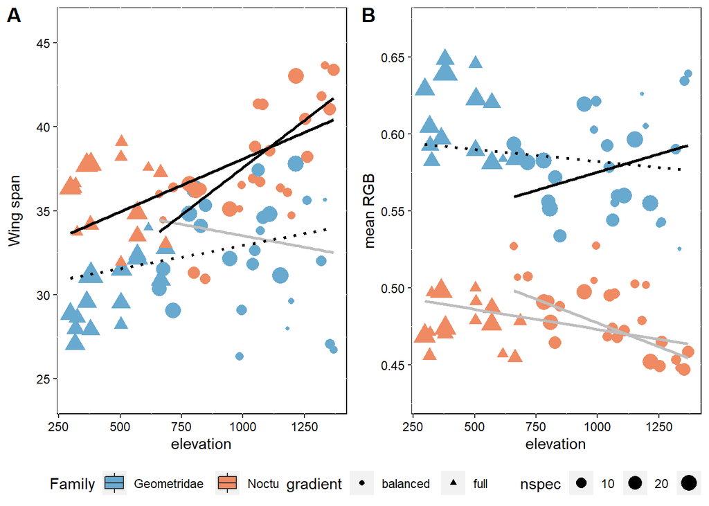

```r
moths_agg_fam$gradient <- "full"
moths_agg_fam[which(moths_agg_fam$Plot%in%plots),"gradient"] <- "balanced"

Wing_full <- ggplot(data=moths_agg_fam[moths_agg_fam$year==2016,],
             aes(elevation, wing_w,colour=Family)) + geom_point(aes(size = nspec, pch=gradient)) +
  scale_colour_manual(breaks = "Family",values = pal) +
  ylab("Wing span")+
  scale_y_continuous(breaks = seq(25, 45, by = 5), limits = c(24,46))+
  geom_smooth(data=moths_agg_fam[moths_agg_fam$Family=="Geometridae"&moths_agg_fam$gradient=="balanced",],method="lm", se=F, col="grey")+
  geom_smooth(data=moths_agg_fam[moths_agg_fam$Family=="Geometridae",],method="lm", se=F, col="black", lty=3)+
  geom_smooth(data=moths_agg_fam[moths_agg_fam$Family=="Noctuidae"&moths_agg_fam$gradient=="balanced",],method="lm", se=F, col="black")+
  geom_smooth(data=moths_agg_fam[moths_agg_fam$Family=="Noctuidae",],method="lm", se=F, col="black")+
  theme(panel.background = element_rect(fill = "white", colour = "black"),
        axis.text = element_text(colour="black"))



RGB_full <- ggplot(data=moths_agg_fam[moths_agg_fam$year==2016,],
             aes(elevation, meanRGB_w,colour=Family)) + geom_point(aes(size = nspec, pch=gradient)) +
  scale_colour_manual(breaks = "Family",values = pal) +
  ylab("mean RGB")+
  scale_y_continuous(breaks = seq(0.45, 0.65, by = 0.05), limits = c(0.43,0.67))+
  geom_smooth(data=moths_agg_fam[moths_agg_fam$Family=="Geometridae"&moths_agg_fam$gradient=="balanced",],method="lm", se=F, col="black")+
  geom_smooth(data=moths_agg_fam[moths_agg_fam$Family=="Geometridae",],method="lm", se=F, col="black", lty=3)+
  geom_smooth(data=moths_agg_fam[moths_agg_fam$Family=="Noctuidae"&moths_agg_fam$gradient=="balanced",],method="lm", se=F, col="grey")+
  geom_smooth(data=moths_agg_fam[moths_agg_fam$Family=="Noctuidae",],method="lm", se=F, col="grey")+
  theme(panel.background = element_rect(fill = "white", colour = "black"),
        axis.text = element_text(colour="black"))


legend_p <- get_legend(
  Wing_full+
    guides(color = guide_legend(nrow = 1)) +
    theme(legend.position = "bottom")
)
lrow2 <- plot_grid(legend_b, legend_p, ncol = 2)

long2016 <- plot_grid(Wing_full+ theme(legend.position="none"), RGB_full+ theme(legend.position="none"), labels = c('A', 'B'),ncol = 2,  align = "v", rel_widths = c(1,1))
long2016 <- plot_grid(long2016, lrow2,ncol = 1, rel_heights = c(1, .1))
long2016
```

```r
ggsave("Output/Appendix_S4_longgradient.tiff",dpi=900,
       width = 166,height=170, unit="mm")
rm(lrow2, long2016, Wing_full, RGB_full)
```

## hierarchial partitioning

we conducted hierarchial partitioning to estimate the relative importance of the co-varying environmental variables on the color lightness and body size of geometrid and noctuid moth assemblages

```r
#install.packages("hier.part")
library(hier.part)
moths_agg_fam_bal$c_temperature_year <- scale(moths_agg_fam_bal$temperature_year)
moths_agg_fam_bal$c_precipitation <- scale(moths_agg_fam_bal$precipitation)
moths_agg_fam_bal$c_crown_cover_ha <- scale(moths_agg_fam_bal$crown_cover_ha)

Noctuid <- droplevels(moths_agg_fam_bal[moths_agg_fam_bal$Family=="Noctuidae",])
hipaWing_Noc <- hier.part(Noctuid$wing_w, Noctuid[,c("c_temperature_year", "c_precipitation", "c_crown_cover_ha")])
```

[figure not shown]

```r
hipaRGB_Noc <- hier.part(Noctuid$wing_w, Noctuid[,c("temperature_year", "precipitation", "crown_cover_ha")])
```

[figure not shown]

```r
Geometrid <- droplevels(moths_agg_fam_bal[moths_agg_fam_bal$Family=="Geometridae",])
hipaWing_Geo <- hier.part(Geometrid$wing_w, Geometrid[,c("temperature_year", "precipitation", "crown_cover_ha")])
hipaRGB_Geo <- hier.part(Geometrid$wing_w, Geometrid[,c("temperature_year", "precipitation", "crown_cover_ha")])
```

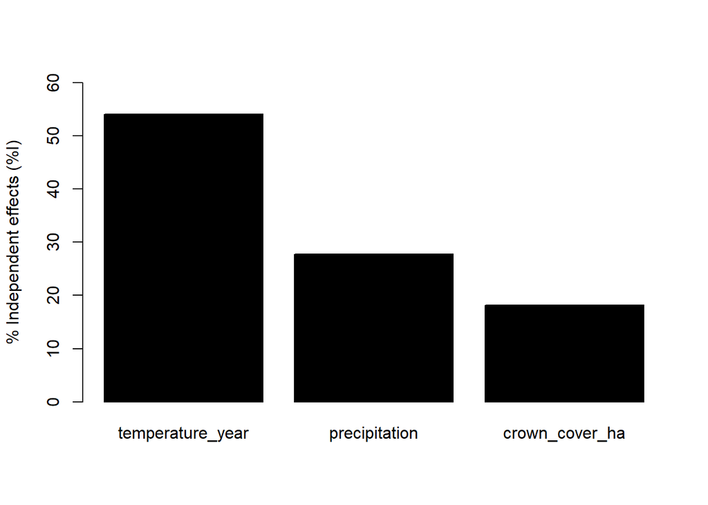

# 4th corner analysis

```r
library(ade4)
Geo <- as.character(traits[traits$Family=="Geometridae","Species"])
Noc <- as.character(traits[traits$Family=="Noctuidae","Species"])

elevation <- env[,c("Plot","elevation")]
elevation <- env[!duplicated(env$Plot),]
elevation$elevation100 <- elevation$elevation/100



LG07 <- moths_M_bal[moths_M_bal$year==2007,names(moths_M_bal)%in%c("Plot",Geo)]
LG16 <- moths_M_bal[moths_M_bal$year==2016,names(moths_M_bal)%in%c("Plot",Geo)]

LN07 <- moths_M_bal[moths_M_bal$year==2007,names(moths_M_bal)%in%c("Plot",Noc)]
LN16 <- moths_M_bal[moths_M_bal$year==2016,names(moths_M_bal)%in%c("Plot",Noc)]

rownames(LG07) <- LG07$Plot; LG07 <- LG07[,-1]
rownames(LG16) <- LG16$Plot; LG16 <- LG16[,-1]
rownames(LN07) <- LN07$Plot; LN07 <- LN07[,-1]
rownames(LN16) <- LN16$Plot; LN16 <- LN16[,-1]


QG07 <- traits[traits$Species%in%colnames(LG07),c("meanRGB","Wing.span"),drop=F]
QG07 <- scale(QG07)
RG07 <- elevation[elevation$Plot%in%row.names(LG07),c("elevation100"),drop=F]
fcG07 <- fourthcorner(data.frame(RG07), data.frame(LG07), data.frame(QG07),nrepet = 9999)

QG16 <- traits[traits$Species%in%colnames(LG16),c("meanRGB","Wing.span"),drop=F]
QG16 <- scale(QG16)
RG16 <- elevation[elevation$Plot%in%row.names(LG16),c("elevation100"),drop=F]
fcG16 <- fourthcorner(data.frame(RG16), data.frame(LG16), data.frame(QG16),nrepet = 9999)

QN07 <- traits[traits$Species%in%colnames(LN07),c("meanRGB","Wing.span"),drop=F]
QN07 <- scale(QN07)
RN07 <- elevation[elevation$Plot%in%row.names(LN07),c("elevation100"),drop=F]
fcN07 <- fourthcorner(data.frame(RN07), data.frame(LN07), data.frame(QN07),nrepet = 9999)

QN16 <- traits[traits$Species%in%colnames(LN16),c("meanRGB","Wing.span"),drop=F]
QN16 <- scale(QN16)
RN16 <- elevation[elevation$Plot%in%row.names(LN16),c("elevation100"),drop=F]
fcN16 <- fourthcorner(data.frame(RN16), data.frame(LN16), data.frame(QN16),nrepet = 9999)

summary(fcG07)
```

```
## Fourth-corner Statistics
## ------------------------
## Permutation method  Comb. 2 and 4  ( 9999  permutations)
##
## Adjustment method for multiple comparisons:   holm
##                       Test Stat         Obs    Std.Obs     Alter Pvalue
## 1   elevation100 / meanRGB    r  0.11979465  0.8549232 two-sided 0.4477
## 2 elevation100 / Wing.span    r -0.06500358 -0.4567321 two-sided 0.6787
##   Pvalue.adj
## 1     0.8954
## 2     0.8954
##
## ---
## Signif. codes:  0 '***' 0.001 '**' 0.01 '*' 0.05 '.' 0.1 ' ' 1
```

```r
summary(fcG16)
```

```
## Fourth-corner Statistics
## ------------------------
## Permutation method  Comb. 2 and 4  ( 9999  permutations)
##
## Adjustment method for multiple comparisons:   holm
##                       Test Stat          Obs     Std.Obs     Alter Pvalue
## 1   elevation100 / meanRGB    r -0.004216065 -0.07277832 two-sided 0.9438
## 2 elevation100 / Wing.span    r  0.056212407  0.64612717 two-sided 0.5465
##   Pvalue.adj
## 1          1
## 2          1
##
## ---
## Signif. codes:  0 '***' 0.001 '**' 0.01 '*' 0.05 '.' 0.1 ' ' 1
```

```r
summary(fcN07)
```

```
## Fourth-corner Statistics
## ------------------------
## Permutation method  Comb. 2 and 4  ( 9999  permutations)
##
## Adjustment method for multiple comparisons:   holm
##                       Test Stat        Obs   Std.Obs     Alter Pvalue
## 1   elevation100 / meanRGB    r -0.3635693 -2.195765 two-sided 0.0158
## 2 elevation100 / Wing.span    r  0.3596754  2.134080 two-sided 0.0203
##   Pvalue.adj
## 1     0.0316 *
## 2     0.0316 *
##
## ---
## Signif. codes:  0 '***' 0.001 '**' 0.01 '*' 0.05 '.' 0.1 ' ' 1
```

```r
summary(fcN16)
```

```
## Fourth-corner Statistics
## ------------------------
## Permutation method  Comb. 2 and 4  ( 9999  permutations)
##
## Adjustment method for multiple comparisons:   holm
##                       Test Stat        Obs   Std.Obs     Alter Pvalue
## 1   elevation100 / meanRGB    r -0.2868582 -1.895101 two-sided 0.0434
## 2 elevation100 / Wing.span    r  0.3466441  2.214796 two-sided 0.0120
##   Pvalue.adj
## 1     0.0434 *
## 2     0.0240 *
##
## ---
## Signif. codes:  0 '***' 0.001 '**' 0.01 '*' 0.05 '.' 0.1 ' ' 1
```

the full gradient

```r
LG16 <- moths_M[moths_M$year==2016,names(moths_M)%in%c("Plot",Geo)]
rownames(LG16) <- LG16$Plot; LG16 <- LG16[,-1]

QG16 <- traits[traits$Species%in%colnames(LG16),c("meanRGB","Wing.span"),drop=F]
QG16 <- scale(QG16)
RG16 <- elevation[elevation$Plot%in%row.names(LG16),c("elevation100"),drop=F]
fcG16 <- fourthcorner(data.frame(RG16), data.frame(LG16), data.frame(QG16),nrepet = 9999)
summary(fcG16)
```

```
## Fourth-corner Statistics
## ------------------------
## Permutation method  Comb. 2 and 4  ( 9999  permutations)
##
## Adjustment method for multiple comparisons:   holm
##                       Test Stat        Obs   Std.Obs     Alter Pvalue
## 1   elevation100 / meanRGB    r -0.1597129 -1.232463 two-sided 0.2354
## 2 elevation100 / Wing.span    r  0.2500176  2.002229 two-sided 0.0337
##   Pvalue.adj
## 1     0.2354
## 2     0.0674 .
##
## ---
## Signif. codes:  0 '***' 0.001 '**' 0.01 '*' 0.05 '.' 0.1 ' ' 1
```

```r
# Noctuids

LN16 <- moths_M[moths_M$year==2016,names(moths_M)%in%c("Plot",Noc)]
rownames(LN16) <- LN16$Plot; LN16 <- LN16[,-1]
QN16 <- traits[traits$Species%in%colnames(LN16),c("meanRGB","Wing.span"),drop=F]
QN16 <- scale(QN16)
RN16 <- elevation[elevation$Plot%in%row.names(LN16),c("elevation100"),drop=F]
fcN16 <- fourthcorner(data.frame(RN16), data.frame(LN16), data.frame(QN16),nrepet = 9999)
summary(fcN16)
```

```
## Fourth-corner Statistics
## ------------------------
## Permutation method  Comb. 2 and 4  ( 9999  permutations)
##
## Adjustment method for multiple comparisons:   holm
##                       Test Stat        Obs   Std.Obs     Alter Pvalue
## 1   elevation100 / meanRGB    r -0.1254251 -1.291281 two-sided 0.2195
## 2 elevation100 / Wing.span    r  0.1897825  1.804444 two-sided 0.0556
##   Pvalue.adj
## 1     0.2195
## 2     0.1112
##
## ---
## Signif. codes:  0 '***' 0.001 '**' 0.01 '*' 0.05 '.' 0.1 ' ' 1
```

# SPECIES-LVL MODELL

#### Datapreparation

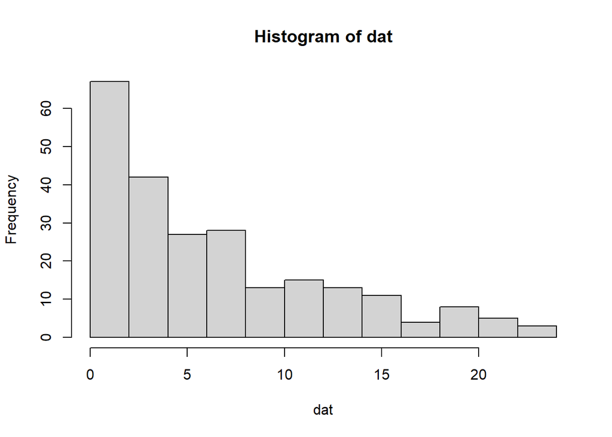

```r
species_lvl_bal$elevation <- as.numeric(species_lvl_bal$elevation)
species_lvl_bal$elevation100 <-species_lvl_bal$elevation/100
species_lvl_bal$year <- as.factor(as.character(species_lvl_bal$year))
species_lvl_bal$Family <- as.factor(species_lvl_bal$Family)
species_lvl_bal$hab_av100 <- species_lvl_bal$hab_av/100

dat <- tapply(species_lvl_bal[species_lvl_bal$abundance>=1,"Plot"], INDEX = list(species_lvl_bal[species_lvl_bal$abundance>=1,"Species"],species_lvl_bal[species_lvl_bal$abundance>=1,"year"] ), length)
hist(dat)
```

```r
dat <- dat[apply(dat, MARGIN = 1, function(x) all(x > 3)), ]    #only species occuring on more than
incl <- rownames(dat)
incl <- incl[!is.na(incl)]
species_lvl_bal <- species_lvl_bal[species_lvl_bal$Species%in%incl,]
length(unique(species_lvl_bal$Species))
```

```
## [1] 62
```

```r
# centre variables
species_lvl_bal[,paste0("c_", c("meanRGB", "Wing.span", "elevation","elevation100", "hab_av", "hab_av100"))] <-
  apply(species_lvl_bal[, c("meanRGB", "Wing.span", "elevation","elevation100" ,"hab_av", "hab_av100")], 2, function(x)scale(x, scale=F))

species_lvl_bal$Species <- as.factor(species_lvl_bal$Species)
species_lvl_bal$Genus <- unlist(lapply(strsplit(as.character(species_lvl_bal$Species), "_"), "[[",1))
species_lvl_bal <- species_lvl_bal[!is.na(species_lvl_bal$hab_av),]
# xestia baja
```

in a next step, we modelled abundance along elevation to check, whether we can assume linear relationships in the analysis

```r
library("mgcv")
```

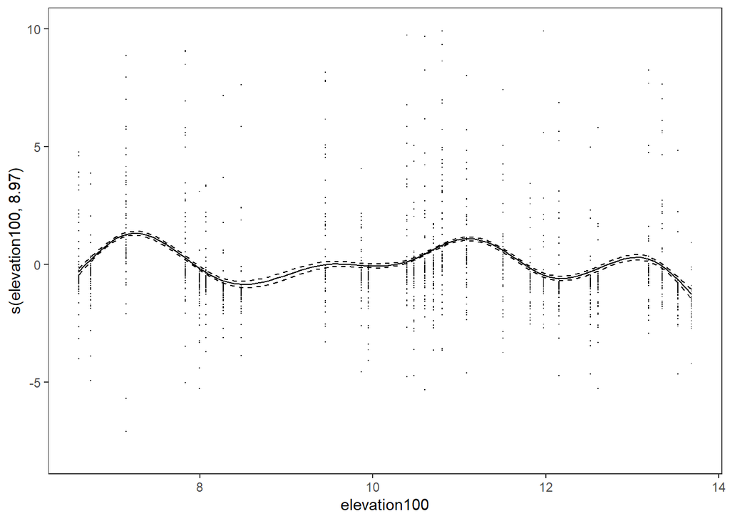

```r
library("mgcViz")
species_lvl$Species <- as.factor(species_lvl$Species)


species_lvl$elevation <- as.numeric(species_lvl$elevation)
species_lvl$elevation100 <-species_lvl$elevation/100
species_lvl$year <- as.factor(as.character(species_lvl$year))
species_lvl$Family <- as.factor(species_lvl$Family)
species_lvl$hab_av100 <- species_lvl$hab_av/100


model.ele.g07 <- gam(abundance ~ s(elevation100)+s(Species, bs="re"), data=species_lvl[species_lvl$Family=="Geometridae"&species_lvl$year=="2007",], family="poisson")
model.ele.g16 <- gam(abundance ~ s(elevation100)+s(Species, bs="re"), data=species_lvl[species_lvl$Family=="Geometridae"&species_lvl$year==2016,], family="poisson")
model.ele.n07 <- gam(abundance ~ s(elevation100)+s(Species, bs="re"), data=species_lvl[species_lvl$Family=="Noctuidae"&species_lvl$year==2007,], family="poisson")
model.ele.n16 <- gam(abundance ~ s(elevation100)+s(Species, bs="re"), data=species_lvl[species_lvl$Family=="Noctuidae"&species_lvl$year==2016,], family="poisson")



peg07 <- getViz(model.ele.g07)
peg16 <- getViz(model.ele.g16)
pen07 <- getViz(model.ele.n07)
pen16 <- getViz(model.ele.n16)

plot(peg07, select = 1) + l_points() + l_fitLine() + l_ciLine()+ylim(-8,10)
```

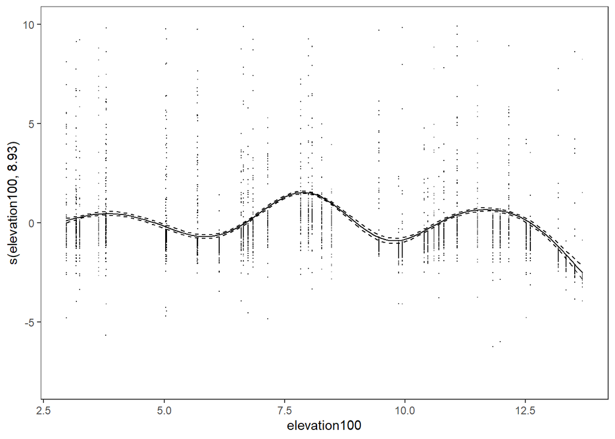

```r
plot(peg16, select = 1) + l_points() + l_fitLine() + l_ciLine()+ylim(-8,10)
```

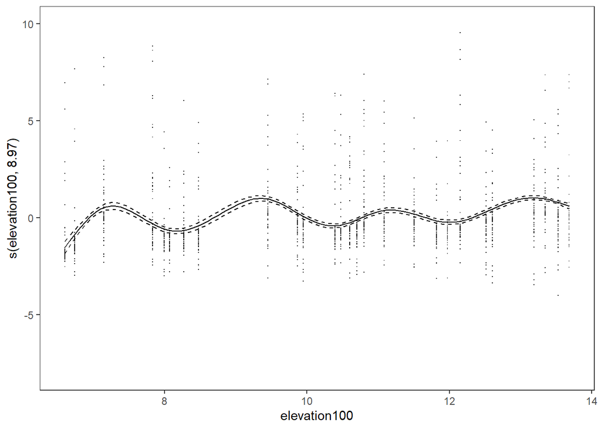

```r
plot(pen07, select = 1) + l_points() + l_fitLine() + l_ciLine()+ylim(-8,10)
```

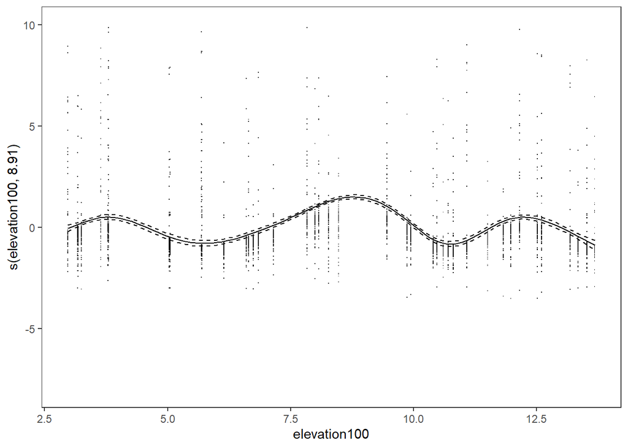

```r
plot(pen16, select = 1) + l_points() + l_fitLine() + l_ciLine()+ylim(-8,10)
```

### model for the balanced data

```r
library(glmmTMB)
tnbin2_orig <-  glmmTMB(abundance ~
                        year+Family+ #collinearity problems....sollte aber eigtl rein
                    year:Family:c_hab_av100+
                    year:Family:c_elevation100+
                    c_Wing.span:year:Family:c_elevation100+                               c_meanRGB:year:Family:c_elevation100+(1|Species),
                  ziformula=~.,
                  data=species_lvl_bal,family="truncated_nbinom2")
summary(tnbin2_orig)
```

```
##  Family: truncated_nbinom2  ( log )
## Formula:
## abundance ~ year + Family + year:Family:c_hab_av100 + year:Family:c_elevation100 +
##     c_Wing.span:year:Family:c_elevation100 + c_meanRGB:year:Family:c_elevation100 +
##     (1 | Species)
## Zero inflation:             ~.
## Data: species_lvl_bal
##
##      AIC      BIC   logLik deviance df.resid
##  11066.4  11315.8  -5492.2  10984.4     3199
##
## Random effects:
##
## Conditional model:
##  Groups  Name        Variance Std.Dev.
##  Species (Intercept) 0.8569   0.9257
## Number of obs: 3240, groups:  Species, 60
##
## Zero-inflation model:
##  Groups  Name        Variance Std.Dev.
##  Species (Intercept) 0.5435   0.7372
## Number of obs: 3240, groups:  Species, 60
##
## Overdispersion parameter for truncated_nbinom2 family (): 0.15
##
## Conditional model:
##                                                        Estimate Std. Error
## (Intercept)                                            0.485693   0.268762
## year2016                                               0.196641   0.122735
## FamilyNoctuidae                                       -0.394688   0.272776
## year2007:FamilyGeometridae:c_hab_av100                 0.931863   0.259101
## year2016:FamilyGeometridae:c_hab_av100                 0.156627   0.271944
## year2007:FamilyNoctuidae:c_hab_av100                   0.346612   0.310242
## year2016:FamilyNoctuidae:c_hab_av100                  -0.301688   0.370078
## year2007:FamilyGeometridae:c_elevation100              0.044387   0.061054
## year2016:FamilyGeometridae:c_elevation100             -0.131096   0.070991
## year2007:FamilyNoctuidae:c_elevation100               -0.141631   0.148923
## year2016:FamilyNoctuidae:c_elevation100               -0.457094   0.164023
## year2007:FamilyGeometridae:c_elevation100:c_Wing.span  0.001473   0.007085
## year2016:FamilyGeometridae:c_elevation100:c_Wing.span -0.007302   0.008524
```

[output cut: 57 more lines]

```
## year2016:FamilyNoctuidae:c_hab_av100                   -1.306  0.19164
## year2007:FamilyGeometridae:c_elevation100               1.808  0.07057 .
## year2016:FamilyGeometridae:c_elevation100               5.798 6.72e-09 ***
## year2007:FamilyNoctuidae:c_elevation100                 1.305  0.19205
## year2016:FamilyNoctuidae:c_elevation100                 2.789  0.00528 **
## year2007:FamilyGeometridae:c_elevation100:c_Wing.span  -1.084  0.27844
## year2016:FamilyGeometridae:c_elevation100:c_Wing.span  -2.361  0.01822 *
## year2007:FamilyNoctuidae:c_elevation100:c_Wing.span    -1.662  0.09661 .
## year2016:FamilyNoctuidae:c_elevation100:c_Wing.span    -2.508  0.01213 *
## year2007:FamilyGeometridae:c_elevation100:c_meanRGB    -0.750  0.45312
## year2016:FamilyGeometridae:c_elevation100:c_meanRGB    -0.949  0.34274
## year2007:FamilyNoctuidae:c_elevation100:c_meanRGB       1.824  0.06812 .
## year2016:FamilyNoctuidae:c_elevation100:c_meanRGB       1.817  0.06921 .
## ---
## Signif. codes:  0 '***' 0.001 '**' 0.01 '*' 0.05 '.' 0.1 ' ' 1
```

### model for full gradient 2016

here, only species used in the balanced analysis were included

```r
species_lvl <- droplevels(species_lvl[species_lvl$year==2016,])
species_lvl <- droplevels(species_lvl[species_lvl$Species%in%incl,])

# centre variables
species_lvl[,paste0("c_", c("meanRGB", "Wing.span", "elevation","elevation100", "hab_av", "hab_av100"))] <-
  apply(species_lvl[, c("meanRGB", "Wing.span", "elevation","elevation100" ,"hab_av", "hab_av100")], 2, function(x)scale(x, scale=F))

tnbin2_2016_full <-  glmmTMB(abundance ~
                        Family+ #collinearity problems....sollte aber eigtl rein
                    Family:c_hab_av100+
                    Family:c_elevation100+
                    c_Wing.span:Family:c_elevation100+                               c_meanRGB:Family:c_elevation100+(1|Species),
                  ziformula=~.,
                  data=species_lvl,family="truncated_nbinom2")
summary(tnbin2_2016_full)
```

```
##  Family: truncated_nbinom2  ( log )
## Formula:
## abundance ~ Family + Family:c_hab_av100 + Family:c_elevation100 +
##     c_Wing.span:Family:c_elevation100 + c_meanRGB:Family:c_elevation100 +
##     (1 | Species)
## Zero inflation:             ~.
## Data: species_lvl
##
##      AIC      BIC   logLik deviance df.resid
##   7450.2   7584.3  -3702.1   7404.2     2497
##
## Random effects:
##
## Conditional model:
##  Groups  Name        Variance Std.Dev.
##  Species (Intercept) 0.6821   0.8259
## Number of obs: 2520, groups:  Species, 60
##
## Zero-inflation model:
##  Groups  Name        Variance Std.Dev.
##  Species (Intercept) 0.4727   0.6876
## Number of obs: 2520, groups:  Species, 60
##
## Overdispersion parameter for truncated_nbinom2 family (): 3.22e-08
##
## Conditional model:
##                                                Estimate Std. Error z value
## (Intercept)                                  -1.455e+01  1.413e+03  -0.010
## FamilyNoctuidae                              -1.967e-01  2.809e-01  -0.700
## FamilyGeometridae:c_hab_av100                 4.379e-01  2.675e-01   1.637
## FamilyNoctuidae:c_hab_av100                  -2.675e-01  4.280e-01  -0.625
## FamilyGeometridae:c_elevation100              1.385e-01  5.160e-02   2.683
## FamilyNoctuidae:c_elevation100               -3.279e-02  1.097e-01  -0.299
## FamilyGeometridae:c_elevation100:c_Wing.span  8.584e-03  6.214e-03   1.381
## FamilyNoctuidae:c_elevation100:c_Wing.span   -4.511e-03  5.258e-03  -0.858
## FamilyGeometridae:c_elevation100:c_meanRGB    1.776e-01  5.388e-01   0.330
## FamilyNoctuidae:c_elevation100:c_meanRGB     -1.690e+00  1.321e+00  -1.280
##                                              Pr(>|z|)
## (Intercept)                                   0.99179
## FamilyNoctuidae                               0.48384
```

[output cut: 21 more lines]

```
## FamilyGeometridae:c_elevation100:c_meanRGB   -0.260858   0.246083  -1.060
## FamilyNoctuidae:c_elevation100:c_meanRGB      0.199111   0.423120   0.471
##                                              Pr(>|z|)
## (Intercept)                                  2.25e-08 ***
## FamilyNoctuidae                              0.967841
## FamilyGeometridae:c_hab_av100                8.74e-14 ***
## FamilyNoctuidae:c_hab_av100                  0.017332 *
## FamilyGeometridae:c_elevation100             0.016473 *
## FamilyNoctuidae:c_elevation100               0.865371
## FamilyGeometridae:c_elevation100:c_Wing.span 0.184225
## FamilyNoctuidae:c_elevation100:c_Wing.span   0.000211 ***
## FamilyGeometridae:c_elevation100:c_meanRGB   0.289125
## FamilyNoctuidae:c_elevation100:c_meanRGB     0.637942
## ---
## Signif. codes:  0 '***' 0.001 '**' 0.01 '*' 0.05 '.' 0.1 ' ' 1
```